# NN_Iris_data

## Why use OneHotEncoder on Iris?

- **Iris dataset labels:** `0`, `1`, `2` for three classes.
- Some ML models (especially **NN with softmax + categorical_crossentropy**) **require one-hot labels** for correct training.

**One-hot encoding converts:**

- `0` → `[1, 0, 0]`
- `1` → `[0, 1, 0]`
- `2` → `[0, 0, 1]`

## Implementation with sklearn

```
from sklearn.preprocessing import OneHotEncoder
from sklearn.datasets import load_iris

iris = load_iris()
y = iris.target.reshape(-1, 1)  # required shape

encoder = OneHotEncoder(sparse=False)
y_encoded = encoder.fit_transform(y)

print(y_encoded[:5])  # Check first few encoded labels
```

```python
from sklearn.datasets import load_iris
from sklearn.preprocessing import OneHotEncoder

iris_data = load_iris()
features = iris_data.data
labels = iris_data.target.reshape(-1,1)

print(labels)
```

```
[[0]
 [0]
 [0]
 [0]
 [0]
 [0]
 [0]
 [0]
 [0]
 [0]
 [0]
 [0]
 [0]
 [0]
 [0]
 [0]
 [0]
 [0]
 [0]
 [0]
 [0]
 [0]
 [0]
 [0]
 [0]
 [0]
 [0]
 [0]
 [0]
 [0]
 [0]
 [0]
 [0]
 [0]
 [0]
 [0]
 [0]
 [0]
 [0]
 [0]
```

[output cut: 95 more lines]

```
 [2]
 [2]
 [2]
 [2]
 [2]
 [2]
 [2]
 [2]
 [2]
 [2]
 [2]
 [2]
 [2]
 [2]
 [2]]
```

```python
encoder = OneHotEncoder()

targets=encoder.fit_transform(labels).toarray()

print(targets)
```

```
[[1. 0. 0.]
 [1. 0. 0.]
 [1. 0. 0.]
 [1. 0. 0.]
 [1. 0. 0.]
 [1. 0. 0.]
 [1. 0. 0.]
 [1. 0. 0.]
 [1. 0. 0.]
 [1. 0. 0.]
 [1. 0. 0.]
 [1. 0. 0.]
 [1. 0. 0.]
 [1. 0. 0.]
 [1. 0. 0.]
 [1. 0. 0.]
 [1. 0. 0.]
 [1. 0. 0.]
 [1. 0. 0.]
 [1. 0. 0.]
 [1. 0. 0.]
 [1. 0. 0.]
 [1. 0. 0.]
 [1. 0. 0.]
 [1. 0. 0.]
 [1. 0. 0.]
 [1. 0. 0.]
 [1. 0. 0.]
 [1. 0. 0.]
 [1. 0. 0.]
 [1. 0. 0.]
 [1. 0. 0.]
 [1. 0. 0.]
 [1. 0. 0.]
 [1. 0. 0.]
 [1. 0. 0.]
 [1. 0. 0.]
 [1. 0. 0.]
 [1. 0. 0.]
 [1. 0. 0.]
```

[output cut: 95 more lines]

```
 [0. 0. 1.]
 [0. 0. 1.]
 [0. 0. 1.]
 [0. 0. 1.]
 [0. 0. 1.]
 [0. 0. 1.]
 [0. 0. 1.]
 [0. 0. 1.]
 [0. 0. 1.]
 [0. 0. 1.]
 [0. 0. 1.]
 [0. 0. 1.]
 [0. 0. 1.]
 [0. 0. 1.]
 [0. 0. 1.]]
```

# Softmax: A Clean Practical Intro

A **structured Colab-ready note** on **what softmax is, how it works, and when to use it in ML/DL.**

## What is Softmax?

Softmax is an **activation function** that:

- Converts **raw scores (logits) into probabilities**.
- Ensures **all output values are between 0 and 1**.
- Ensures **all probabilities sum to 1**.

## The Formula

Given logits: $$ z = [z_1, z_2, ..., z_n] $$

Softmax for class ( j ) is: $$ \sigma(z)_j = \frac{e^{z_j}}{\sum_{k=1}^{n} e^{z_k}} $$

## Why exponential?

- Emphasizes larger logits (higher confidence).
- Stabilizes probability distribution.

## When to use Softmax?

**Use softmax in:**

- **Multi-class classification problems** where:
  - Each sample **belongs to exactly one class**.
  - Classes are **mutually exclusive**.
- As the **activation function in the last layer** of your neural network when you want **probability outputs across multiple classes**.

Typically paired with:

- **Loss:** `categorical_crossentropy` (one-hot labels).
- **OR** `sparse_categorical_crossentropy` (integer labels).

## When NOT to use softmax:

- **Binary classification** → Use `sigmoid` instead.
- **Multi-label classification (sample can belong to multiple classes simultaneously)** → Use **multiple `sigmoid` outputs** instead.

## Example in Keras

### Model:

```
from tensorflow.keras import Sequential
from tensorflow.keras.layers import Dense

model = Sequential([
    Dense(32, activation='relu', input_shape=(4,)),
    Dense(3, activation='softmax')
])
```

```python
print(features.shape)
```

```
(150, 4)
```

```python
from keras.models import Sequential
from keras.layers import Dense
import matplotlib.pyplot as plt

model = Sequential([
    Dense(8,activation='relu',input_shape=(4,)),
    Dense(3,activation='softmax',input_dim=8)

])
```

```python
from keras.optimizers import Adam

optimizer = Adam(learning_rate=0.001)
```

```python
from sklearn.model_selection import train_test_split
train_features,test_features,train_targets,test_targets= train_test_split(features,targets,test_size=0.2,random_state=41)
```

```python
print(train_targets)
```

```
[[0. 1. 0.]
 [0. 1. 0.]
 [0. 0. 1.]
 [0. 1. 0.]
 [0. 0. 1.]
 [1. 0. 0.]
 [0. 0. 1.]
 [0. 1. 0.]
 [0. 0. 1.]
 [0. 1. 0.]
 [0. 1. 0.]
 [0. 1. 0.]
 [1. 0. 0.]
 [0. 0. 1.]
 [0. 0. 1.]
 [1. 0. 0.]
 [0. 0. 1.]
 [0. 1. 0.]
 [1. 0. 0.]
 [0. 1. 0.]
 [0. 0. 1.]
 [0. 1. 0.]
 [0. 0. 1.]
 [1. 0. 0.]
 [1. 0. 0.]
 [0. 0. 1.]
 [0. 0. 1.]
 [1. 0. 0.]
 [0. 1. 0.]
 [1. 0. 0.]
 [1. 0. 0.]
 [0. 1. 0.]
 [1. 0. 0.]
 [0. 1. 0.]
 [0. 0. 1.]
 [1. 0. 0.]
 [0. 1. 0.]
 [0. 1. 0.]
 [0. 0. 1.]
 [1. 0. 0.]
```

[output cut: 65 more lines]

```
 [0. 1. 0.]
 [1. 0. 0.]
 [0. 0. 1.]
 [0. 1. 0.]
 [0. 1. 0.]
 [0. 0. 1.]
 [0. 1. 0.]
 [0. 1. 0.]
 [0. 0. 1.]
 [0. 0. 1.]
 [1. 0. 0.]
 [0. 1. 0.]
 [0. 1. 0.]
 [0. 1. 0.]
 [0. 0. 1.]]
```

```python
model.compile(loss='categorical_crossentropy',optimizer=optimizer,metrics=['accuracy'])
```

# Why use `loss='categorical_crossentropy'`

**Use when:**

- Multi-class, single-label classification.
- Labels are **one-hot encoded**.
- Model output uses **`softmax`**.

**Why:**

- Measures how well predicted probabilities match true labels.
- Penalizes wrong confident predictions.
- Perfectly matches `softmax` outputs, expecting probabilities that sum to 1.

**Formula:** $$ L = - \sum_{i} y_i \log(\hat{y}_i) $$ where:

- $ y_i $: one-hot true label.
- $ \hat{y}_i $: softmax output.

**Alternative:** Use `sparse_categorical_crossentropy` if using **integer labels (`0,1,2`)** instead of one-hot.

```python
model.fit(train_features,train_targets,epochs=10000,batch_size=20,verbose=2)
```

[output not shown]

[output cut: 2446 more lines]

[output not shown]

```
<keras.src.callbacks.history.History at 0x7921cf77ea50>
```

```python
results = model.evaluate(test_features,test_targets)
```

```
1/1 ━━━━━━━━━━━━━━━━━━━━ 0s 198ms/step - accuracy: 0.9333 - loss: 0.2636
```

# Interpreting `model.evaluate()` Output

## ✅What it returns:

A **list of metrics** in the same order as specified in:

```
model.compile(loss='...', metrics=['...'])
```

```python
print(results)
```

```
[0.26362743973731995, 0.9333333373069763]
```

```python
print(model.predict(test_features))
```

```
1/1 ━━━━━━━━━━━━━━━━━━━━ 0s 65ms/step
[[2.63841223e-11 5.29648096e-04 9.99470353e-01]
 [1.07675007e-16 6.09391400e-12 9.99999940e-01]
 [6.38327875e-18 2.13282560e-12 9.99999940e-01]
 [3.76536892e-11 9.99999940e-01 3.59171892e-08]
 [3.08881914e-14 4.09442258e-08 9.99999940e-01]
 [7.09260428e-12 9.99999940e-01 8.26012490e-13]
 [2.67521755e-10 7.51475804e-03 9.92485106e-01]
 [7.21354018e-11 9.99999940e-01 1.79255952e-08]
 [4.42978683e-12 2.27753080e-05 9.99977171e-01]
 [1.45976533e-17 5.74625037e-13 9.99999940e-01]
 [2.79785972e-09 1.23335183e-01 8.76664698e-01]
 [9.99999940e-01 4.52292327e-12 2.34585298e-16]
 [9.99999940e-01 6.90403901e-10 1.77846510e-14]
 [1.02925370e-10 9.99999940e-01 3.69216420e-12]
 [9.99999940e-01 1.08985008e-08 9.73534404e-14]
 [1.38423806e-09 9.46124911e-01 5.38751110e-02]
 [9.99999940e-01 2.61687783e-09 1.69488514e-14]
 [2.34436220e-10 7.84426089e-03 9.92155671e-01]
 [9.99999940e-01 3.68949967e-14 1.42845423e-17]
 [9.99964654e-01 3.53264259e-05 1.02013675e-11]
 [9.91400798e-12 9.99999940e-01 4.93065224e-13]
 [4.20224427e-16 6.78589684e-11 9.99999940e-01]
 [9.99999940e-01 8.44444847e-10 4.80279031e-14]
 [9.99999940e-01 1.77185870e-11 1.15694875e-15]
 [1.22109300e-09 1.00000000e+00 1.56103463e-11]
 [8.12328991e-13 1.00000000e+00 4.86603867e-13]
 [7.82011816e-11 9.99999762e-01 2.55411095e-07]
 [9.08446148e-12 1.00000000e+00 2.82274340e-13]
 [1.00000000e+00 6.75233827e-12 3.53751108e-16]
 [9.54364504e-11 9.99998808e-01 1.20644017e-06]]
```

```python
import numpy as np
prediction = model.predict(test_features)
predicted_classes=np.argmax(prediction,axis=1)
```

```
1/1 ━━━━━━━━━━━━━━━━━━━━ 0s 37ms/step
```

```python
print(predicted_classes)
```

```
[2 2 2 1 2 1 2 1 2 2 2 0 0 1 0 1 0 2 0 0 1 2 0 0 1 1 1 1 0 1]
```

```python
true_classes = np.argmax(test_targets,axis=1)
```

```python
print(true_classes)
```

```
[2 2 2 1 2 1 2 1 2 2 2 0 0 1 0 2 0 1 0 0 1 2 0 0 1 1 1 1 0 1]
```

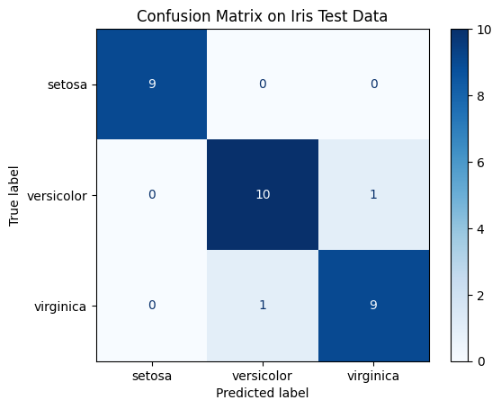

```
Test Accuracy: 93.33%
```

```python
from sklearn.metrics import confusion_matrix, ConfusionMatrixDisplay, accuracy_score

cm = confusion_matrix(true_classes, predicted_classes)
disp = ConfusionMatrixDisplay(confusion_matrix=cm, display_labels=iris_data.target_names)

disp.plot(cmap='Blues', values_format='d')
plt.title("Confusion Matrix on Iris Test Data")
plt.show()


acc = accuracy_score(true_classes, predicted_classes)
print(f"Test Accuracy: {acc * 100:.2f}%")
```